## Goal

The goal of this project is to predict the manner in which people do the exercise. This is the “classes” variable in the training set. We may use any of the other variables to predict with. We create a report describing all the analysis and in particular the prediction of 20 different test cases.

The five different ‘classe’ factors in this dataset are: * Exactly according to the specification (Class A) * Throwing the elbows to the front (Class B) * Lifting the dumbbell only halfway (Class C) * Lowering the dumbbell only halfway (Class D) * Throwing the hips to the front (Class E)

## Data Preprocessing

The training data set is partitioned into a training set (80% of the data) for the modeling process and a validation set (20%) for testing purposes.The validation set will allow us to pick the most accurate model.

## Clean Data

1. Check columns with NAs, Null and #DIV values and apply “0” value to all of them
2. Remove first 7 and the last one columns in order to carry on the preprocessing step
3. Convert all ‘integer’ columns to ‘numeric’
4. Check the predictor with the NON ZERO VARIANCE function
5. Define dataset with needed data only

## Analysis

I have chosen to test three models including the classification tree, a generalize boosted regression model, and a random forest model. I chose these because I wanted to see how they behave in comparassing.

### Classification Tree

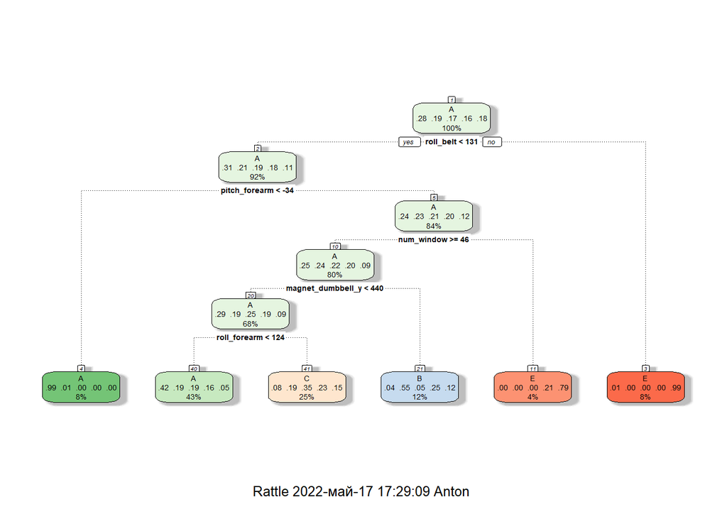

```
##           Reference
## Prediction    A    B    C    D    E
##          A 1022   11   81    0    2
##          B  323  272  164    0    0
##          C  331   22  331    0    0
##          D  276  112  227    0   28
##          E   63   63  152    0  443
```

```
##  Accuracy
## 0.5271476
```

### Generalized Boosted Regression Model (GBM)

```
## A gradient boosted model with multinomial loss function.
## 150 iterations were performed.
## There were 53 predictors of which 53 had non-zero influence.
```

```
## Confusion Matrix and Statistics
##
##           Reference
## Prediction    A    B    C    D    E
##          A 1112   11    0    0    0
##          B    4  738    8    1    4
##          C    0    9  676    8    2
##          D    0    1    0  633    7
##          E    0    0    0    1  708
##
## Overall Statistics
##
##                Accuracy : 0.9857
##                  95% CI : (0.9815, 0.9892)
##     No Information Rate : 0.2845
##     P-Value [Acc > NIR] : < 2.2e-16
##
##                   Kappa : 0.9819
##
##  Mcnemar's Test P-Value : NA
##
## Statistics by Class:
##
##                      Class: A Class: B Class: C Class: D Class: E
## Sensitivity            0.9964   0.9723   0.9883   0.9844   0.9820
## Specificity            0.9961   0.9946   0.9941   0.9976   0.9997
## Pos Pred Value         0.9902   0.9775   0.9727   0.9875   0.9986
## Neg Pred Value         0.9986   0.9934   0.9975   0.9970   0.9960
## Prevalence             0.2845   0.1935   0.1744   0.1639   0.1838
## Detection Rate         0.2835   0.1881   0.1723   0.1614   0.1805
## Detection Prevalence   0.2863   0.1925   0.1772   0.1634   0.1807
## Balanced Accuracy      0.9962   0.9835   0.9912   0.9910   0.9908
```

### Random Forest

From the random forest model we can see that using 27 variables in the model provided the highest accuracy. Across 500 trees this model performed significantly better than the classification tree. The accuracy for the random forest was 99.8%.

```
##
## Call:
##  randomForest(x = x, y = y, mtry = min(param$mtry, ncol(x)))
##                Type of random forest: classification
##                      Number of trees: 500
## No. of variables tried at each split: 27
##
##         OOB estimate of  error rate: 0.2%
## Confusion matrix:
##      A    B    C    D    E  class.error
## A 4463    0    0    0    1 0.0002240143
## B    6 3027    5    0    0 0.0036208032
## C    0    5 2733    0    0 0.0018261505
## D    0    0    9 2563    1 0.0038865138
## E    0    0    0    5 2881 0.0017325017
```

```
## Confusion Matrix and Statistics
##
##           Reference
## Prediction    A    B    C    D    E
##          A 1115    1    0    0    0
##          B    0  758    1    0    0
##          C    0    1  683    0    0
##          D    0    0    0  643    0
##          E    0    0    0    0  721
##
## Overall Statistics
##
##                Accuracy : 0.9992
##                  95% CI : (0.9978, 0.9998)
##     No Information Rate : 0.2842
##     P-Value [Acc > NIR] : < 2.2e-16
##
##                   Kappa : 0.999
##
##  Mcnemar's Test P-Value : NA
##
## Statistics by Class:
##
##                      Class: A Class: B Class: C Class: D Class: E
## Sensitivity            1.0000   0.9974   0.9985   1.0000   1.0000
## Specificity            0.9996   0.9997   0.9997   1.0000   1.0000
## Pos Pred Value         0.9991   0.9987   0.9985   1.0000   1.0000
## Neg Pred Value         1.0000   0.9994   0.9997   1.0000   1.0000
## Prevalence             0.2842   0.1937   0.1744   0.1639   0.1838
## Detection Rate         0.2842   0.1932   0.1741   0.1639   0.1838
## Detection Prevalence   0.2845   0.1935   0.1744   0.1639   0.1838
## Balanced Accuracy      0.9998   0.9985   0.9991   1.0000   1.0000
```

### Conclusion

The model accuracy:

Classification Tree Model: 52.7%

Generalized Boosted Model: 98.57%

Random Forest Model: 99.92%

The random forest model has the best accuracy!

```
##  [1] B A B A A E D B A A B C B A E E A B B B
## Levels: A B C D E
```